# USDA Projections and Customer Analytics

Julie Wisch

8/21/2020

## USDA Projection Availability

The USDA publishes corn planting projections annually. It is the Customer Analytics team’s understanding that these models are developed in October, preliminarily released in November, and re-released in final form in February. When the USDA projections are published, the USDA applies their annual model to an 8 to 11 year range, depending on the year of publication. Projections start with model application to data 1 year prior to the model publication up to 7 - 10 years after the model publication. These projections are publicly available on the USDA’s webpage: https://data.ers.usda.gov/reports.aspx?ID=17821 . The first publicly available year of model projections is 1997.

For example, in October of 2019, the modeling team at the USDA met and developed a corn acreage model. In November of 2019, the team released preliminary projections, with finalized projections coming in February of 2020 for the number of acres planted in March of 2020. They projected the number of acres planted in the US of corn in March 2019 (year -1), all the way up to the number of acres of corn planted in the US in March 2029 (year +9 ).

The USDA also conducts annual surveys in the first two weeks of March in order to project the total number of acres planted in the US for that spring. These surveys are re-conducted in June and August of the same year in order to update the planting totals. The USDA uses these probabilistic surveys to calculate the total number of acres planted annually. These totals can be found here: https://quickstats.nass.usda.gov/results/823A5054-B8F9-3341-AC31-8B03C6990BC1 . For our efforts at modeling the total planting acreage in the US, we will consider these values to be the “ground truth”. The first available year of planted acres is 1926. For the case of the survey data, the year corresponds with the March where the corn was planted. If corn was planted in March of 2020, the year in this dataset is 2020.

### Historical Acreage Plantings

Historical results of the USDA’s annual planting survey are shown below.

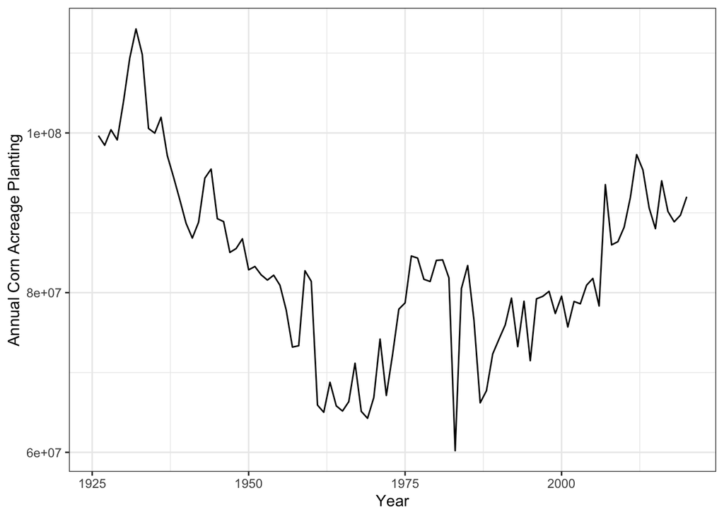

### Model Projections vs Historical Reality

Model projections are only available consistently starting in 1996. We were also able to obtain projections form 1993 and 1995. Projections from 1997 on are publicly available online; years 1993, 1995 and 1996 were provided via email exchange with the USDA.

In the figures below, the heading shows the number of years between the model and the projection, the ground truth is on the x axis, and the USDA’s model projection is on the y axis. A diagonal line cuts across the plot. If a model projection is absolutely perfect, the point will lie on the diagonal line. If the model overpredicts, the point will be above the diagonal. Conversely, if the model underpredicts, the model will be below the diagonal.

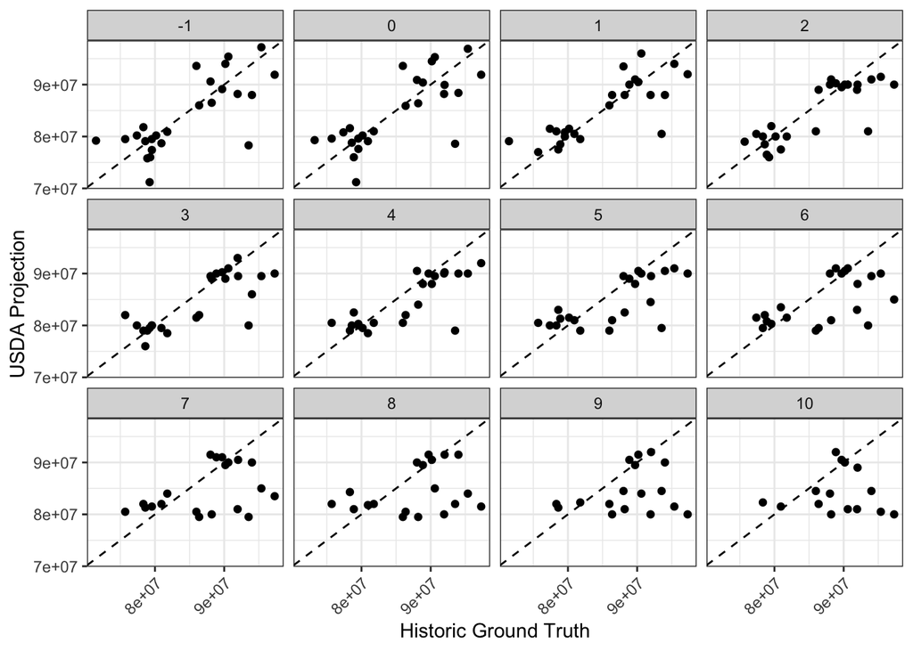

We can quantify the USDA’s model performance using several error metrics. Below we show the mean absolute error (MAE), which describes how many million acres per year, on average, the model and reality differ, as well as the mean squared error (MSE), root mean squared error (RMSE), and mean absolute percent error (MAPE).

USDA Model Projection Quality

| MAEinMillionAcres. | MSE | RMSE | MAPEinPercent | TimeBetweenAnalysisandProjection |
| --- | --- | --- | --- | --- |
| 3.67 | 2.438901e+13 | 4938523 | 4.32 | -1 |
| 3.56 | 2.287225e+13 | 4782494 | 4.15 | 0 |
| 2.84 | 1.709284e+13 | 4134349 | 3.29 | 1 |
| 2.83 | 1.470787e+13 | 3835084 | 3.24 | 2 |
| 2.95 | 1.892798e+13 | 4350630 | 3.34 | 3 |
| 3.04 | 1.815599e+13 | 4260985 | 3.45 | 4 |
| 3.70 | 2.389939e+13 | 4888700 | 4.22 | 5 |
| 4.24 | 3.220931e+13 | 5675324 | 4.74 | 6 |
| 4.99 | 4.248031e+13 | 6517692 | 5.58 | 7 |
| 5.29 | 4.905955e+13 | 7004252 | 5.91 | 8 |
| 5.52 | 5.417208e+13 | 7360169 | 6.06 | 9 |
| 6.13 | 6.414908e+13 | 8009312 | 6.68 | 10 |

## Value - Add Opportunities for Customer Analytics

In addition to access to the USDA’s publicly available models, the Customer Analytics team can access sales data for roughly one third of the US corn market. In theory, sales should directly correspond to acres planted, meaning we should have real time insights that the USDA does not have.

#### Where can the Customer Analytics team add value?

- By creating a model in the fall for the following March that performs better than the +1 year model that is available before the USDA November estimates are released
- By creating a model in the fall or winter for the following March that performs better than the 0 year model

### Customer Analytics Model - Trying to Beat the +1 Year Model

- Net national brand orders in September, 1 and 2 years prior
- Net national brand orders in October, 1 and 2 years prior
- Net national brand orders in November, 1 and 2 years prior
- Net national brand orders in December, 1 and 2 years prior
- Running total of national brand orders for Sept - Oct, 1 and 2 years prior
- Running total of national brand orders for Sept - Nov, 1 and 2 years prior
- Running total of national brand orders for Sept - Dec, 1 and 2 years prior
- USDA Projections for the upcoming year

Further, we will simulate the progression of the fall. We will create a model with the above features. This will be the baseline model for the upcoming year, called the “BeforeOrders” model. As sales data becomes available, we will add in September, October, and November sales. By the end of November, the 0 year USDA model becomes available. At that point, it probably makes more sense to use the newer published numbers and shift modeling approaches.

For these models, we will train on a range of windows, using between 6 and 9 years of data. We will calculate error metrics based on this sliding window. In the plotted error metrics below, we see that both the random forest and XGBoost models outperform the published USDA numbers. In all cases, even using sales data from 1 and 2 years prior are sufficiently informative as to make the BeforeOrders model better than the published USDA model. The XGBoost model performs better than the random forest model for nearly all cases, so we will discuss that further.

The BeforeOrder model does not actually improve with the addition of September Order data. Once October data is available, the model improves - at least for the 6 and 7 year windows. For the longer time windows (where the model is then only tested on 1 or 2 years of data), XGBoost may have overtrained on the training data. We do not see an additional lift from adding November data.

From these results, we can conclude the following:

- The Customer Analytics team can produce a model that outperforms the publicly available USDA model in the fall
- The Customer Analytics team can refine this model at the end of October, providing estimates that are within roughly 1 million acres of reality, on average. This represents a mean average percent error of less than 1.5%.

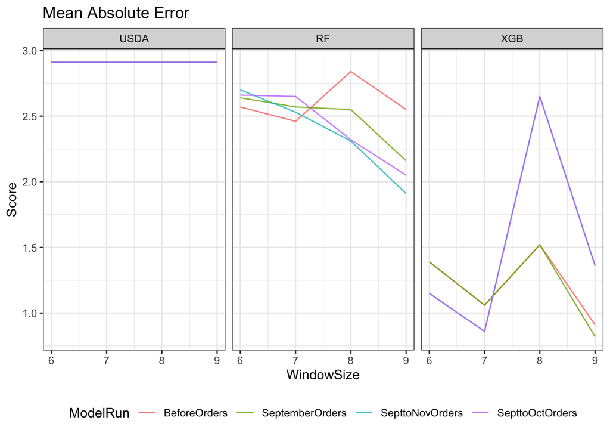

### Customer Analytics Model - Trying to Beat the 0 Year Model

The model described in the previous section outperforms the projections made by the USDA for planting one year out. In November, the USDA will release new projections for the following March. The objective of this model is to take the new USDA Projections, released in November, and augment them with our sales information in order to see if we can improve projections.

Similar to before, we will start with a base model, in this case a model that uses both the new USDA projections and sales records from September through November. We will subsequently add December, January, and February orders. And again we find that both models are better than the USDA numbers, and the XGBoost model is the best performing model. Much like before when the addition of one month’s sales records does not yield an improvement, but two months’ sales records does; we see that the model that includes sales records through January has a consistently strong performance. If we evaluate these model performances cautiously, we state that we can, on average, make projections within one million acres of reality. If we evaluate these model performances optimistically, we state that in January we can make projections within half a million acres, which is to say, within 1% of actual national corn acreage.

From these results, we can conclude the following:

- The Customer Analytics team can produce a model that outperforms the publicly available updated USDA model in the spring
- The Customer Analytics team can refine this model at the end of January, providing estimates that are within roughly 0.5 - 1 million acres of reality. This represents a mean average percent error of less than 1%.

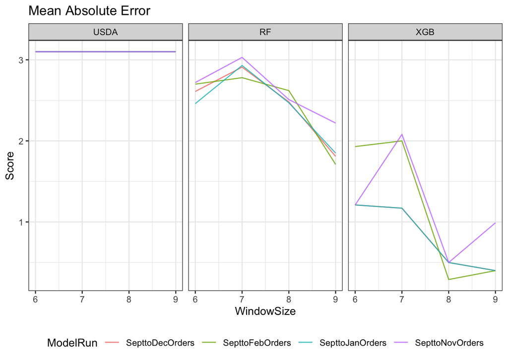